# Final Project

Jean Luo and Yi Zhang

2021-11-08

##### Load and examine data

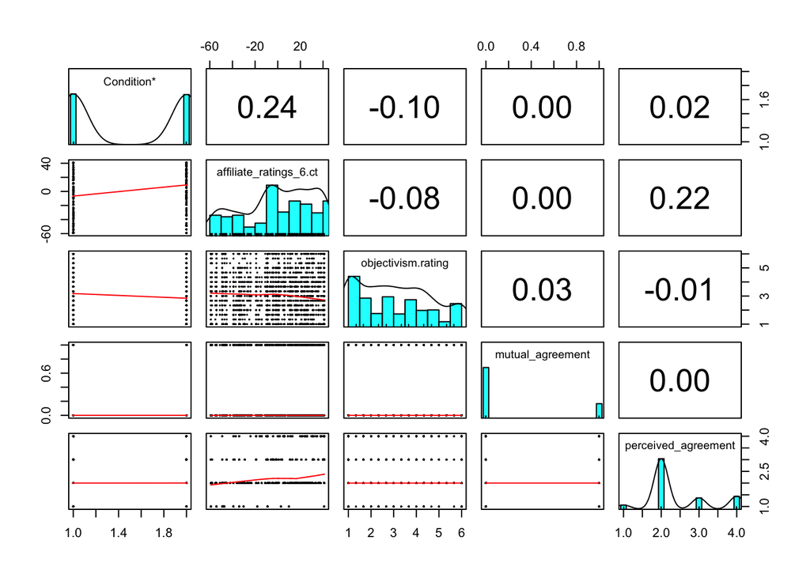

#### Testing model assumptions

##### ICC

```r
#Baseline model
m0 <- lmer(objectivism.rating ~ (1|statement) + (1|id), data = data)
vc_m0 <- as.data.frame(VarCorr(m0))
# ICC/Deff (person; cluster size = 9)
icc_person <- vc_m0$vcov[1] / sum(vc_m0$vcov)
# ICC (item; cluster size = 367)
icc_item <- vc_m0$vcov[2] / sum(vc_m0$vcov)
# ICC (person + item)
c("ICC(person + item)" = sum(vc_m0$vcov[1:2]) / sum(vc_m0$vcov)) #.40
```

```
## ICC(person + item)
##           0.404038
```

```r
#ICC andd design effect for person
c("ICC(person)" = icc_person,
  "Deff(person)" = (1 - icc_item) + (9 - 1) * icc_person)
```

```
##  ICC(person) Deff(person)
##    0.3140867    3.4227419
```

```r
#ICC and design effect for item
c("ICC(item)" = icc_item,
  "Deff(item)" = (1 - icc_person) + (367 - 1) * icc_item)
```

```
##   ICC(item)  Deff(item)
##  0.08995134 33.60810292
```

ICC for `person` is .31, which means that 31% of the variance in objectivity rating was at the between-person level. The corresponding design effect was 3.42.

ICC for `item` is .09, meaning that 9% of the variance in objectivity rating was at the between-item level. The corresponding design effect was 33.61.

Since both design effects are larger than 1.1, we include both the person and item levels in our multilevel model.

#### Visualizing the Data

The figure below whos the variation in objectivism rating at both the person and item levels.

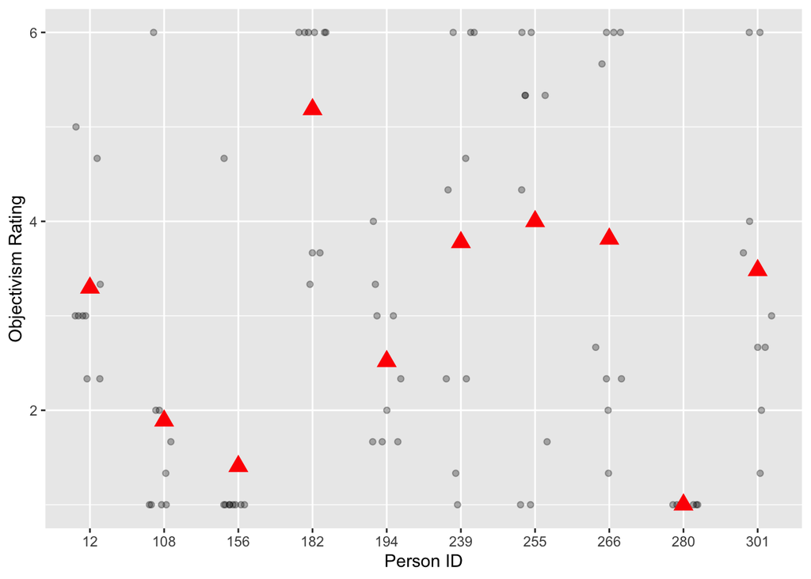

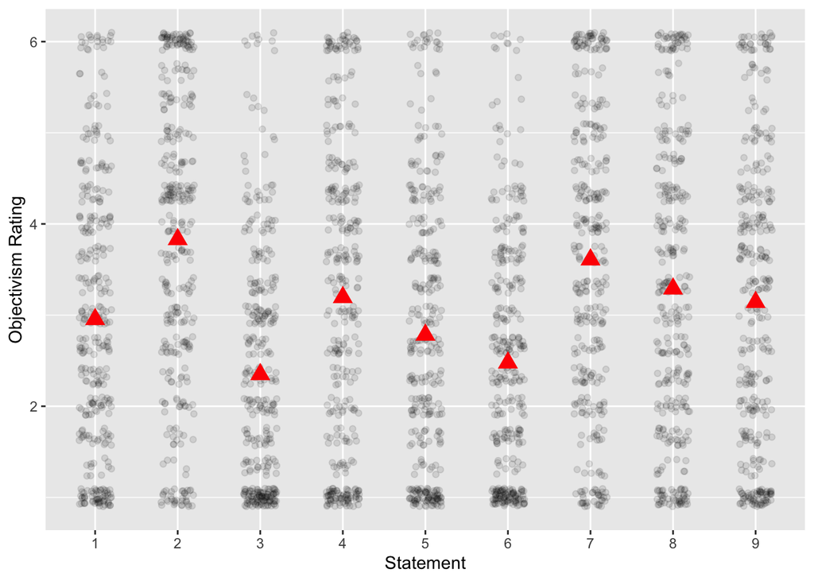

#### Multilevel model

**Model equations**:

Repeated-Measure level (Lv 1):
$$\text{objectivism}_{j,k} = \beta_{j, k} + e_{jk}$$
Between-cell (Person $\times$ Item) level (Lv 2):
$$\beta_{0(j, k)} = \gamma_{00} + \beta_{1j}Condition + \beta_{2k}perceived\_agreement + u_{0j} + v_{0k}$$
Person level (Lv 2a) random slopes
$$\begin{aligned}
\beta_{1j} = \gamma_{10} + u_{1j}
\end{aligned}$$
Item level (Lv2b) random slopes
$$\beta_{2k} = \gamma_{20} + v_{2k}$$

##### Baseline model

First, we fit a random-intercept model using condition at the person-level and perceived agreement at the item-level to predict objectivism ratings.

```r
# Fit a linear growth model with no random slopes
m1 <- lmer(objectivism.rating ~ Condition + perceived_agreement + (1|statement) + (1|id), data = data)
summary(m1)
```

```
## Linear mixed model fit by REML. t-tests use Satterthwaite's method [
## lmerModLmerTest]
## Formula:
## objectivism.rating ~ Condition + perceived_agreement + (1 | statement) +
##     (1 | id)
##    Data: data
##
## REML criterion at convergence: 11083.6
##
## Scaled residuals:
##     Min      1Q  Median      3Q     Max
## -2.8679 -0.6522 -0.0717  0.6353  3.8244
##
## Random effects:
##  Groups    Name        Variance Std.Dev.
##  id        (Intercept) 0.7961   0.8923
##  statement (Intercept) 0.2336   0.4833
##  Residual              1.5474   1.2440
## Number of obs: 3186, groups:  id, 354; statement, 9
##
## Fixed effects:
##                          Estimate Std. Error        df t value Pr(>|t|)
## (Intercept)               3.25821    0.23389  33.35489  13.930 1.85e-15 ***
## ConditionCOOPERATE WITH  -0.31398    0.10460 351.00001  -3.002  0.00288 **
## perceived_agreement      -0.01341    0.06350 351.00001  -0.211  0.83288
## ---
## Signif. codes:  0 '***' 0.001 '**' 0.01 '*' 0.05 '.' 0.1 ' ' 1
##
## Correlation of Fixed Effects:
##             (Intr) CCOOPW
## CCOOPERATEW -0.211
## prcvd_grmnt -0.653 -0.017
```

##### Linearity

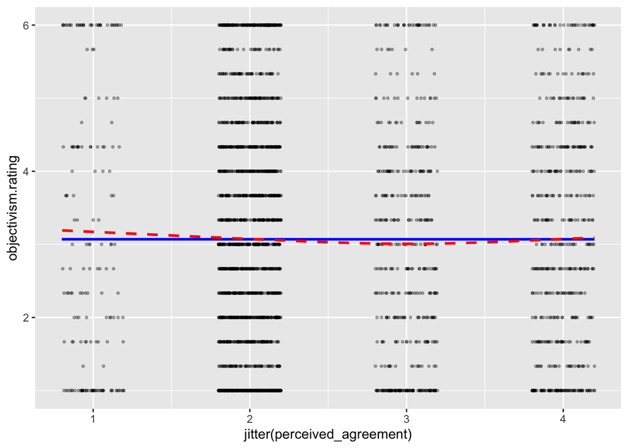

```r
augment(m1) %>%
  ggplot(aes(x = jitter(perceived_agreement), y = objectivism.rating)) +
  geom_point(size = 0.7, alpha = 0.3) +
  geom_smooth(col = "blue", se = FALSE) + # blue line from data
  geom_smooth(aes(y = .fitted),
    col = "red",
    se = FALSE, linetype = "dashed"
  )  # red line from model
```

The marginal model plot above shows the outcome variable, objectivism rating, against the predictor perceived agreement. The lines are roughly similar to each other, so there is no need to include extra curvillinear terms.

##### Homogeneity of variance

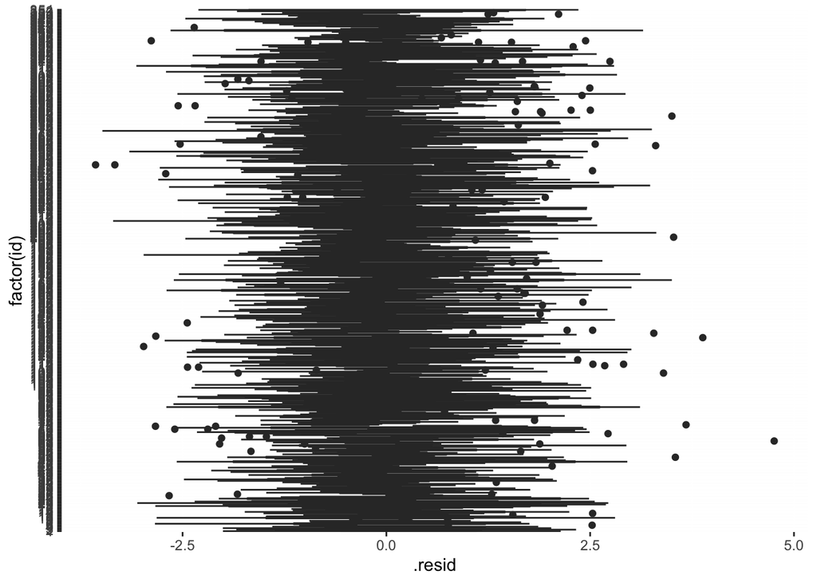

```r
augment(m1) %>%
  ggplot(aes(x = factor(id), y = .resid)) +
  geom_boxplot() +
  coord_flip()
```

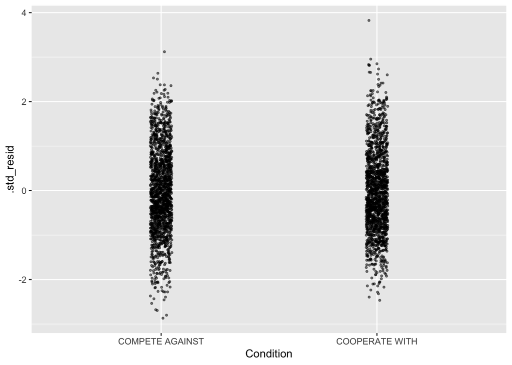

```r
augment(m1) %>%
  mutate(.std_resid = resid(m1, scaled = TRUE)) %>%
  ggplot(aes(x = Condition, y = .std_resid)) +
  # use `geom_jitter` for discrete predictor
  geom_jitter(size = 0.7, alpha = 0.5, width = 0.05)
```

Here, we see that most of the standardized residuals are between -3 and 3, so there are not a lot of outliers. Also, the variability of the residuals looks roughly similar across clusters.

##### Normality

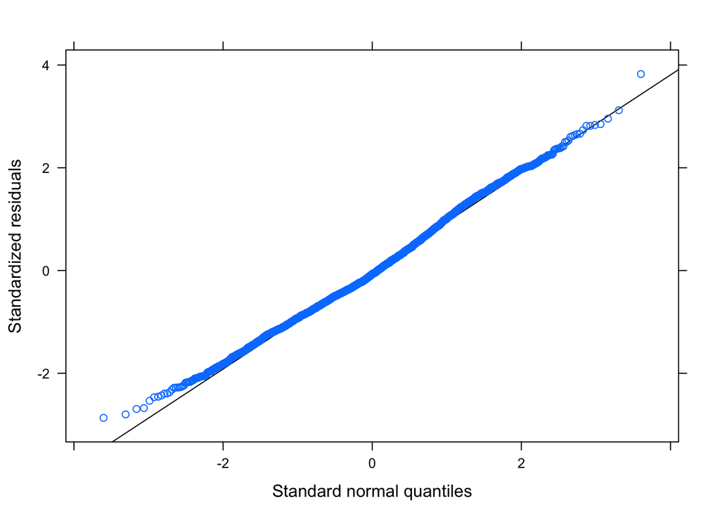

```r
library(lattice)  # need this package to use the built-in functions
qqmath(m1)  # just use the `qqmath()` function on the fitted model
```

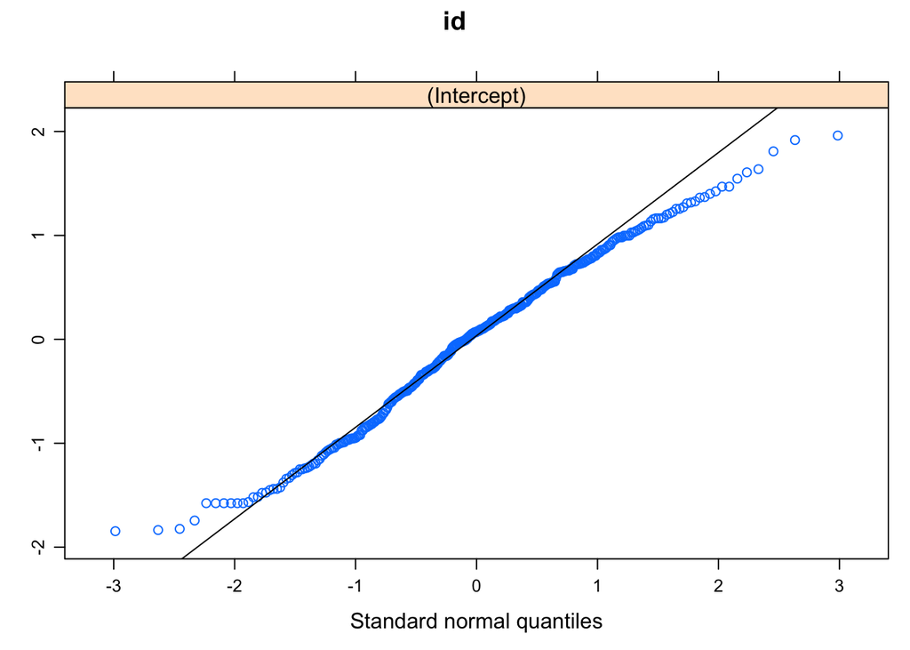

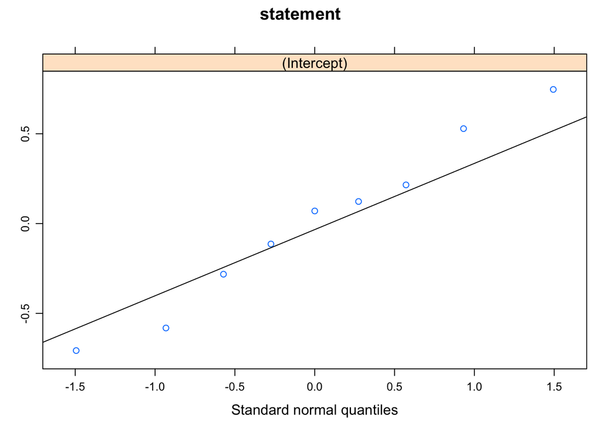

```r
qqmath(ranef(m1, condVar = FALSE),
       panel = function(x) {
         panel.qqmath(x)
         panel.qqmathline(x)
       })
```

In the Q-Q plots above, we see the residuals roughly follow the 45-degree line, so normality does not appear to be an issue.

##### Summary table

```r
msummary_mixed <- function(models, output = "default", coef_map = NULL, ...) {
  if (is.null(coef_map)) {
    if (!"list" %in% class(models)) {
      models <- list(models)
    }
    for (model in models) {
      coef_map <- union(coef_map, tidy(model)$term)
    }
    ranef_index <- grep("^(sd|cor)__", x = coef_map)
    coef_map <- c(coef_map[-ranef_index], coef_map[ranef_index])
    names(coef_map) <- coef_map
  } else {
    ranef_index <- grep("^(sd|cor)__", x = names(coef_map))
  }
  rows <- data.frame(term = c("Fixed Effects", "Random Effects"))
  rows <- cbind(rows, rbind(
    rep("", length(models)),
    rep("", length(models))
  ))
  length_fes <- length(coef_map) - length(ranef_index)
  if ("statistic" %in% names(list(...)) && is.null(list(...)$statistic)) {
    attr(rows, "position") <- c(1, (length_fes + 1))
  } else {
    attr(rows, "position") <- c(1, (length_fes + 1) * 2)
  }
  if (output == "latex" || knitr::is_latex_output()) {
    coef_map <- gsub("_", "-", coef_map)
  }
  modelsummary::msummary(models,
    output = output, coef_map = coef_map,
    add_rows = rows, ...
  )
}



msummary_mixed(list("random-intercept" = m0,
                    "model 1" = m1))
```

|  | random-intercept | model 1 |
| --- | --- | --- |
| Fixed Effects |  |  |
| (Intercept) | 3.070 | 3.258 |
|  | (0.170) | (0.234) |
| ConditionCOOPERATE WITH |  | −0.314 |
|  |  | (0.105) |
| perceived_agreement |  | −0.013 |
|  |  | (0.064) |
| Random Effects |  |  |
| sd__(Intercept) | 0.483 | 0.483 |
|  | 0.483 | 0.892 |
|  | 0.903 | 0.483 |
|  | 0.903 | 0.892 |
| sd__Observation | 1.244 | 1.244 |
| AIC | 11094.3 | 11095.6 |
| BIC | 11118.6 | 11132.0 |
| Log.Lik. | −5543.146 | −5541.819 |
| REMLcrit | 11086.292 | 11083.637 |

##### Testing random slopes

```r
# Fit a linear growth model with random slope= of time
m1.rs1 <- lmer(objectivism.rating ~ Condition + perceived_agreement + (Condition|statement) + (1|id), data = data,
               control = lmerControl()
)

m1.rs2 <- lmer(objectivism.rating ~ Condition + perceived_agreement + (perceived_agreement|statement) + (1|id), data = data
)

#test
ranova(m1.rs1)
```

|  | npar | logLik | AIC | LRT | Df | Pr(>Chisq) |
| --- | --- | --- | --- | --- | --- | --- |
|  | 8 | -5541.799 | 11099.60 | NA | NA | NA |
| Condition in (Condition \| statement) | 6 | -5541.819 | 11095.64 | 0.04020978 | 2 | 9.800959e-01 |
| (1 \| id) | 7 | -5894.720 | 11803.44 | 705.84272003 | 1 | 1.603887e-155 |

```r
ranova(m1.rs2)
```

|  | npar | logLik | AIC | LRT | Df | Pr(>Chisq) |
| --- | --- | --- | --- | --- | --- | --- |
|  | 8 | -5541.739 | 11099.48 | NA | NA | NA |
| perceived_agreement in (perceived_agreement \| statement) | 6 | -5541.819 | 11095.64 | 0.1588632 | 2 | 9.236412e-01 |
| (1 \| id) | 7 | -5894.681 | 11803.36 | 705.8836495 | 1 | 1.571352e-155 |

Neither the random slopes for `Condition` nor ‘perceived_agreement’ were significant.